# Informe 3

José Matus

05 de julio

```r
library(tidyverse)
library(GGally)
library(corrplot)
library(dplyr)
library(ggplot2)
library(car)
library(readxl)
library(nortest)
library(ggfortify)
library(lmtest)
library(gamlss)
library(ppcor)
library(MASS)

datos <- read_excel("C:/Users/jose/Downloads/MATUS_TORO_JOSE.xlsx")
```

# Análisis de variable

## Selección de la variable

Para definir la variable, primero quitaremos la variable año de la base de datos debido a que los datos estudiados fueron extraídos todos del año 2013 por lo tanto, esta variable, no aporta nada al estudio que se desea realizar

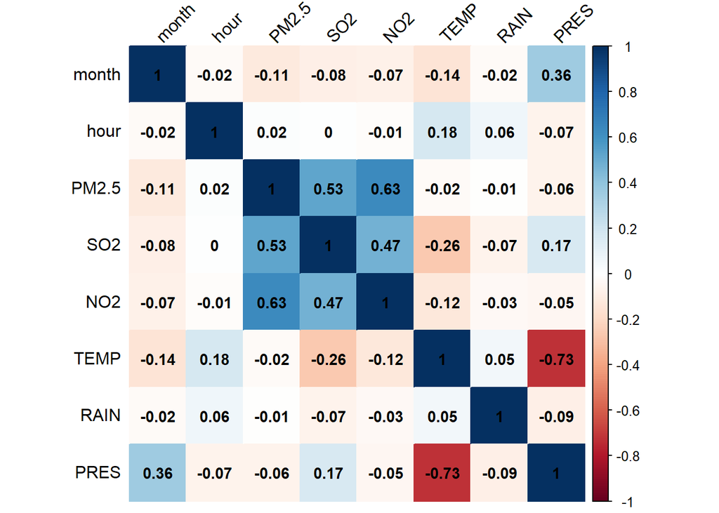

```r
aire <- datos %>% dplyr :: select(-year)
corrplot(cor(aire),
         method="color",
         addCoef.col = "black",
         number.cex=0.9,
         tl.col="black",
         tl.srt=45)
```

Al analizar el cuadro de correlación podemos observar que la variable que mayor relación presenta con las demás es la variable PRES, por ende, escogeremos esta como la variable dependiente ya que es probable de que las demás variables puedan predecirla de una buena forma

## Limpieza de datos

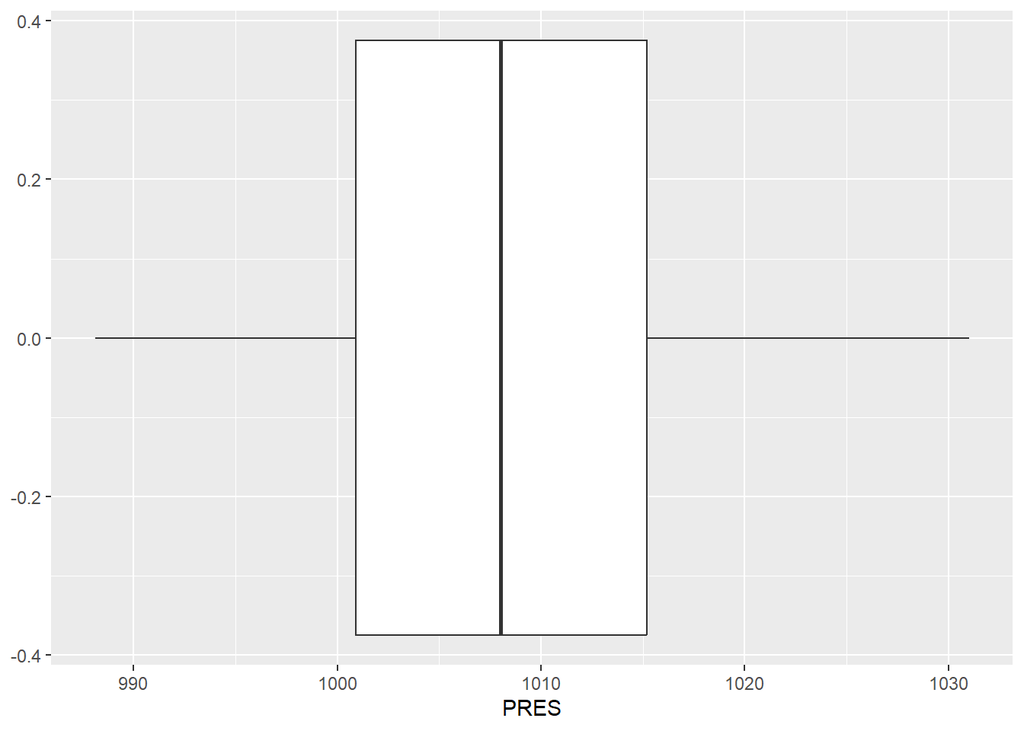

```r
cajaPres = datos %>%
  ggplot(aes(y=PRES)) +
  geom_boxplot() +
  coord_flip()
cajaPres
```

Observando el diagrama de caja se puede notar que no existen datos atípicos, por lo tanto, se realizaran los modelos de regresión con la cantidad total de los datos

# Modelos

## Mod1 (Lineal simple)

Para el modelo de regresión lineal simple escogeremos la variable TEMP (temperatura) como predictor ya que, como se pudo observar en el cuadro de correlación, esta es la variable que tiene una relación mas fuerte con la presión (-0.73)

```r
modelo1 <- lm(PRES ~ TEMP, data = aire)
summary(modelo1) #0.5304
```

```
##
## Call:
## lm(formula = PRES ~ TEMP, data = aire)
##
## Residuals:
##     Min      1Q  Median      3Q     Max
## -25.297  -4.375  -0.006   4.791  16.869
##
## Coefficients:
##               Estimate Std. Error t value Pr(>|t|)
## (Intercept) 1019.04044    0.34628 2942.82   <2e-16 ***
## TEMP          -0.67623    0.01837  -36.82   <2e-16 ***
## ---
## Signif. codes:  0 '***' 0.001 '**' 0.01 '*' 0.05 '.' 0.1 ' ' 1
##
## Residual standard error: 6.316 on 1199 degrees of freedom
## Multiple R-squared:  0.5306, Adjusted R-squared:  0.5303
## F-statistic:  1356 on 1 and 1199 DF,  p-value: < 2.2e-16
```

Teniendo en cuenta el R^2 obtenido, a continuación crearemos un nuevo modelo que excluya los datos atípicos del modelo anterior puesto que, como se puede ver en el grafico siguiente, existen algunos datos atípicos que tal vez estén afectando el modelo

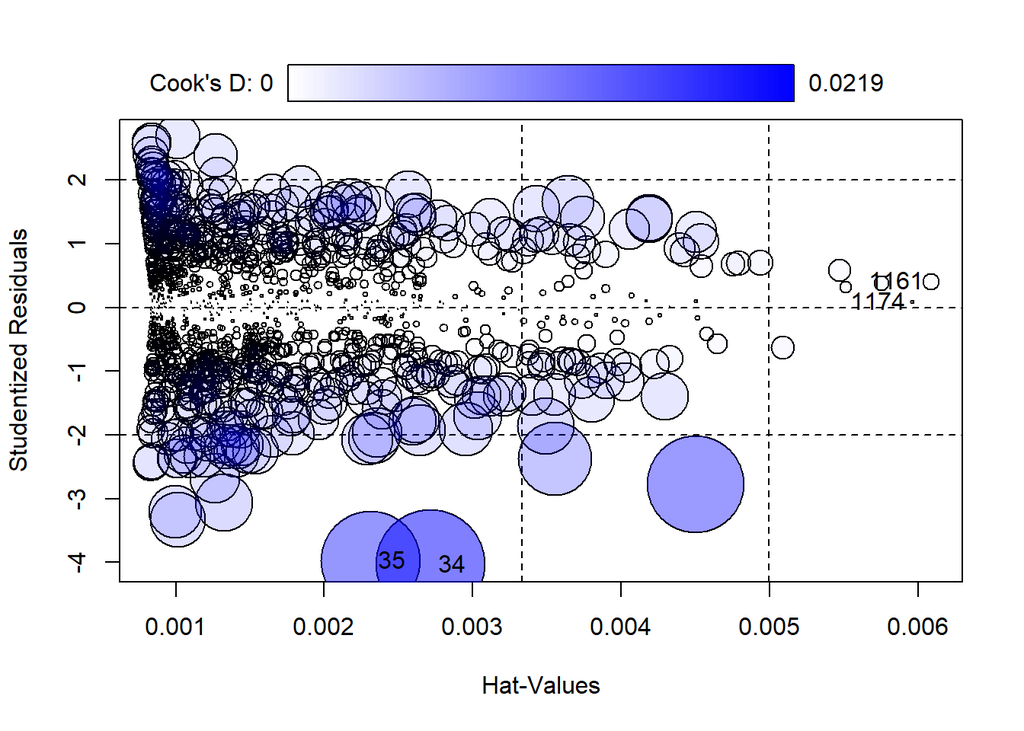

```r
puntosAtipicos <- influencePlot(modelo1)
```

```r
inffluyentesAtipcos = as.numeric(rownames(puntosAtipicos))
modeloSinPuntoM1 = lm(PRES ~ TEMP , data = aire %>%
              dplyr :: slice(-inffluyentesAtipcos))

summary(modeloSinPuntoM1) #0.5375
```

```
##
## Call:
## lm(formula = PRES ~ TEMP, data = aire %>% dplyr::slice(-inffluyentesAtipcos))
##
## Residuals:
##      Min       1Q   Median       3Q      Max
## -20.9964  -4.4179  -0.0579   4.8147  16.8036
##
## Coefficients:
##               Estimate Std. Error t value Pr(>|t|)
## (Intercept) 1019.16734    0.34510  2953.2   <2e-16 ***
## TEMP          -0.68166    0.01828   -37.3   <2e-16 ***
## ---
## Signif. codes:  0 '***' 0.001 '**' 0.01 '*' 0.05 '.' 0.1 ' ' 1
##
## Residual standard error: 6.242 on 1195 degrees of freedom
## Multiple R-squared:  0.5379, Adjusted R-squared:  0.5375
## F-statistic:  1391 on 1 and 1195 DF,  p-value: < 2.2e-16
```

Debido a que al quitar los datos atípicos el R^2 aumenta ligeramente, escogeremos al modelo sin los puntos influyentes como el mod1, además de que al ver la gráfica que aparecerá a continuación pareciera que el modelo se ajusta bien

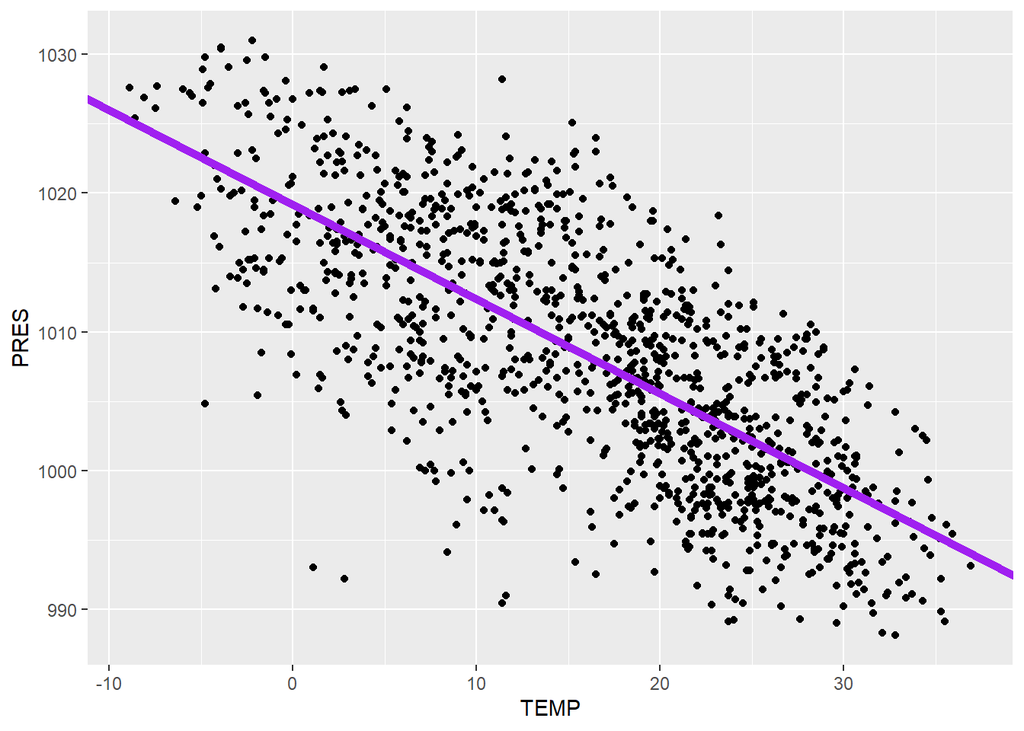

```r
aire %>%
  ggplot(aes(TEMP,PRES))+
  geom_point()+
  geom_abline(intercept = modeloSinPuntoM1$coefficients[1],
              slope = modeloSinPuntoM1$coefficients[2],
              col="purple",linewidth=2)
```

```r
mod1 = modeloSinPuntoM1
```

Finalmente, el mod1 se definiría de la siguiente forma:

PRES = 1019.16734 - 0.68166(TEMP)

Donde el valor de la presión disminuye en 0.68166 cada vez que la temperatura suba una unidad y en caso de que esta sea cero, la presión tomaria el valor de 1019.16734

## Mod2 (Lineal múltiple)

A continuación, se realizará el modelo de regresión lineal múltiple empezando por el modelo que contempla todas las variables

```r
modeloFull <- lm(PRES ~ .,data = aire) # 0.6166
summary(modeloFull)
```

```
##
## Call:
## lm(formula = PRES ~ ., data = aire)
##
## Residuals:
##      Min       1Q   Median       3Q      Max
## -20.2321  -4.1435   0.2699   4.1118  15.0015
##
## Coefficients:
##               Estimate Std. Error  t value Pr(>|t|)
## (Intercept)  1.014e+03  7.442e-01 1362.182  < 2e-16 ***
## month        8.292e-01  6.020e-02   13.775  < 2e-16 ***
## hour         8.189e-02  2.500e-02    3.275  0.00109 **
## PM2.5        9.139e-04  3.133e-03    0.292  0.77058
## SO2          2.551e-02  7.946e-03    3.211  0.00136 **
## NO2         -4.374e-02  6.647e-03   -6.581 6.98e-11 ***
## TEMP        -6.504e-01  1.794e-02  -36.258  < 2e-16 ***
## RAIN        -6.196e-01  2.256e-01   -2.747  0.00611 **
## ---
## Signif. codes:  0 '***' 0.001 '**' 0.01 '*' 0.05 '.' 0.1 ' ' 1
##
## Residual standard error: 5.706 on 1193 degrees of freedom
## Multiple R-squared:  0.6189, Adjusted R-squared:  0.6166
## F-statistic: 276.7 on 7 and 1193 DF,  p-value: < 2.2e-16
```

```r
vif(modeloFull)
```

```
##    month     hour    PM2.5      SO2      NO2     TEMP     RAIN
## 1.041710 1.038525 1.929012 1.584232 1.755422 1.168954 1.011021
```

Ya que el modeloFull consta con un vif muy bajo en cada variable podemos concluir que este no posee multicolinealidad por lo tanto no es necesario ajustar el modelo con el ppcor

Observando el modeloFull, procederemos a quitar las variables con menos significancia, creando modelos individuales sin ellas, para luego crear un último modelo sin todas estas variables (hour, PM2.5, SO2, RAIN)

**Modelo sin PM2.5**

```r
ma = lm(PRES ~., data = aire %>% dplyr :: select(-PM2.5)) # 0.6169
summary(ma)
```

```
##
## Call:
## lm(formula = PRES ~ ., data = aire %>% dplyr::select(-PM2.5))
##
## Residuals:
##      Min       1Q   Median       3Q      Max
## -20.2371  -4.1306   0.2573   4.1216  14.9605
##
## Coefficients:
##               Estimate Std. Error  t value Pr(>|t|)
## (Intercept)  1.014e+03  7.424e-01 1365.370  < 2e-16 ***
## month        8.284e-01  6.011e-02   13.782  < 2e-16 ***
## hour         8.192e-02  2.499e-02    3.278 0.001077 **
## SO2          2.634e-02  7.418e-03    3.551 0.000399 ***
## NO2         -4.274e-02  5.698e-03   -7.502 1.22e-13 ***
## TEMP        -6.497e-01  1.774e-02  -36.625  < 2e-16 ***
## RAIN        -6.174e-01  2.254e-01   -2.739 0.006246 **
## ---
## Signif. codes:  0 '***' 0.001 '**' 0.01 '*' 0.05 '.' 0.1 ' ' 1
##
## Residual standard error: 5.704 on 1194 degrees of freedom
## Multiple R-squared:  0.6188, Adjusted R-squared:  0.6169
## F-statistic: 323.1 on 6 and 1194 DF,  p-value: < 2.2e-16
```

```r
vif(ma)
```

```
##    month     hour      SO2      NO2     TEMP     RAIN
## 1.039454 1.038509 1.381951 1.290909 1.143795 1.009861
```

**Modelo sin RAIN**

```r
mb = lm(PRES ~., data = aire %>% dplyr :: select(-RAIN)) # 0.6145
summary(mb)
```

```
##
## Call:
## lm(formula = PRES ~ ., data = aire %>% dplyr::select(-RAIN))
##
## Residuals:
##      Min       1Q   Median       3Q      Max
## -20.2293  -4.1753   0.2537   4.1380  15.0183
##
## Coefficients:
##               Estimate Std. Error  t value Pr(>|t|)
## (Intercept)  1.014e+03  7.460e-01 1358.732  < 2e-16 ***
## month        8.327e-01  6.035e-02   13.797  < 2e-16 ***
## hour         7.782e-02  2.503e-02    3.110 0.001918 **
## PM2.5        6.224e-04  3.140e-03    0.198 0.842925
## SO2          2.688e-02  7.952e-03    3.380 0.000747 ***
## NO2         -4.338e-02  6.664e-03   -6.510  1.1e-10 ***
## TEMP        -6.511e-01  1.799e-02  -36.198  < 2e-16 ***
## ---
## Signif. codes:  0 '***' 0.001 '**' 0.01 '*' 0.05 '.' 0.1 ' ' 1
##
## Residual standard error: 5.722 on 1194 degrees of freedom
## Multiple R-squared:  0.6165, Adjusted R-squared:  0.6145
## F-statistic: 319.9 on 6 and 1194 DF,  p-value: < 2.2e-16
```

```r
vif(mb)
```

```
##    month     hour    PM2.5      SO2      NO2     TEMP
## 1.041264 1.034882 1.926798 1.578001 1.754742 1.168744
```

**Modelo sin RAIN y PM2.5**

```r
mb2 = lm(PRES ~., data = aire %>% dplyr :: select(-RAIN,-PM2.5)) # 0.6148
summary(mb2)
```

```
##
## Call:
## lm(formula = PRES ~ ., data = aire %>% dplyr::select(-RAIN, -PM2.5))
##
## Residuals:
##      Min       1Q   Median       3Q      Max
## -20.2326  -4.1689   0.2772   4.1374  14.9904
##
## Coefficients:
##               Estimate Std. Error  t value Pr(>|t|)
## (Intercept)  1.014e+03  7.443e-01 1361.884  < 2e-16 ***
## month        8.321e-01  6.026e-02   13.809  < 2e-16 ***
## hour         7.785e-02  2.502e-02    3.112  0.00190 **
## SO2          2.744e-02  7.427e-03    3.695  0.00023 ***
## NO2         -4.270e-02  5.713e-03   -7.475 1.49e-13 ***
## TEMP        -6.506e-01  1.778e-02  -36.583  < 2e-16 ***
## ---
## Signif. codes:  0 '***' 0.001 '**' 0.01 '*' 0.05 '.' 0.1 ' ' 1
##
## Residual standard error: 5.719 on 1195 degrees of freedom
## Multiple R-squared:  0.6165, Adjusted R-squared:  0.6148
## F-statistic: 384.1 on 5 and 1195 DF,  p-value: < 2.2e-16
```

```r
vif(mb2)
```

```
##    month     hour      SO2      NO2     TEMP
## 1.038938 1.034845 1.377889 1.290900 1.143401
```

**Modelo sin RAIN, PM2.5 y hour**

```r
mb3 = lm(PRES ~., data = aire %>% dplyr :: select(-RAIN,-PM2.5,-hour)) # 0.612
summary(mb3)
```

```
##
## Call:
## lm(formula = PRES ~ ., data = aire %>% dplyr::select(-RAIN, -PM2.5,
##     -hour))
##
## Residuals:
##      Min       1Q   Median       3Q      Max
## -20.5556  -4.1901   0.3426   4.1275  14.7515
##
## Coefficients:
##               Estimate Std. Error  t value Pr(>|t|)
## (Intercept)  1.014e+03  7.095e-01 1429.665  < 2e-16 ***
## month        8.341e-01  6.047e-02   13.794  < 2e-16 ***
## SO2          2.862e-02  7.445e-03    3.844 0.000127 ***
## NO2         -4.295e-02  5.733e-03   -7.491 1.32e-13 ***
## TEMP        -6.405e-01  1.755e-02  -36.495  < 2e-16 ***
## ---
## Signif. codes:  0 '***' 0.001 '**' 0.01 '*' 0.05 '.' 0.1 ' ' 1
##
## Residual standard error: 5.74 on 1196 degrees of freedom
## Multiple R-squared:  0.6133, Adjusted R-squared:  0.612
## F-statistic: 474.3 on 4 and 1196 DF,  p-value: < 2.2e-16
```

```r
vif(mb3)
```

```
##    month      SO2      NO2     TEMP
## 1.038816 1.374318 1.290654 1.105603
```

**Modelo sin hour**

```r
mc = lm(PRES ~., data = aire %>% dplyr :: select(-hour)) # 0.6135
summary(mc)
```

```
##
## Call:
## lm(formula = PRES ~ ., data = aire %>% dplyr::select(-hour))
##
## Residuals:
##      Min       1Q   Median       3Q      Max
## -20.5701  -4.1598   0.3024   4.1212  14.7551
##
## Coefficients:
##               Estimate Std. Error  t value Pr(>|t|)
## (Intercept)  1.014e+03  7.102e-01 1428.329  < 2e-16 ***
## month        8.317e-01  6.044e-02   13.761  < 2e-16 ***
## PM2.5        9.540e-04  3.146e-03    0.303   0.7618
## SO2          2.679e-02  7.968e-03    3.362   0.0008 ***
## NO2         -4.404e-02  6.673e-03   -6.600 6.18e-11 ***
## TEMP        -6.400e-01  1.773e-02  -36.106  < 2e-16 ***
## RAIN        -5.758e-01  2.261e-01   -2.547   0.0110 *
## ---
## Signif. codes:  0 '***' 0.001 '**' 0.01 '*' 0.05 '.' 0.1 ' ' 1
##
## Residual standard error: 5.729 on 1194 degrees of freedom
## Multiple R-squared:  0.6154, Adjusted R-squared:  0.6135
## F-statistic: 318.5 on 6 and 1194 DF,  p-value: < 2.2e-16
```

```r
vif(mc)
```

```
##    month    PM2.5      SO2      NO2     TEMP     RAIN
## 1.041552 1.928982 1.580428 1.755093 1.131984 1.007474
```

**Modelo sin hour y PM2.5**

```r
mc2 = lm(PRES ~., data = aire %>% dplyr :: select(-hour,-PM2.5)) # 0.6138
summary(mc2)
```

```
##
## Call:
## lm(formula = PRES ~ ., data = aire %>% dplyr::select(-hour, -PM2.5))
##
## Residuals:
##      Min       1Q   Median       3Q      Max
## -20.5754  -4.1706   0.3188   4.1111  14.7122
##
## Coefficients:
##               Estimate Std. Error  t value Pr(>|t|)
## (Intercept)  1.014e+03  7.085e-01 1431.848  < 2e-16 ***
## month        8.308e-01  6.035e-02   13.767  < 2e-16 ***
## SO2          2.765e-02  7.438e-03    3.718  0.00021 ***
## NO2         -4.300e-02  5.720e-03   -7.517  1.1e-13 ***
## TEMP        -6.392e-01  1.752e-02  -36.486  < 2e-16 ***
## RAIN        -5.735e-01  2.259e-01   -2.539  0.01125 *
## ---
## Signif. codes:  0 '***' 0.001 '**' 0.01 '*' 0.05 '.' 0.1 ' ' 1
##
## Residual standard error: 5.727 on 1195 degrees of freedom
## Multiple R-squared:  0.6154, Adjusted R-squared:  0.6138
## F-statistic: 382.5 on 5 and 1195 DF,  p-value: < 2.2e-16
```

```r
vif(mc2)
```

```
##    month      SO2      NO2     TEMP     RAIN
## 1.039301 1.377928 1.290670 1.106587 1.006298
```

**Modelo sin SO2**

```r
md = lm(PRES ~., data = aire %>% dplyr :: select(-SO2)) # 0.6136
summary(md)
```

```
##
## Call:
## lm(formula = PRES ~ ., data = aire %>% dplyr::select(-SO2))
##
## Residuals:
##      Min       1Q   Median       3Q      Max
## -20.1403  -4.1183   0.3179   4.1223  15.0004
##
## Coefficients:
##               Estimate Std. Error  t value Pr(>|t|)
## (Intercept)  1.014e+03  7.375e-01 1375.033  < 2e-16 ***
## month        8.150e-01  6.027e-02   13.523  < 2e-16 ***
## hour         8.582e-02  2.507e-02    3.423 0.000639 ***
## PM2.5        4.509e-03  2.938e-03    1.535 0.125124
## NO2         -3.991e-02  6.564e-03   -6.080 1.62e-09 ***
## TEMP        -6.666e-01  1.729e-02  -38.559  < 2e-16 ***
## RAIN        -6.650e-01  2.260e-01   -2.942 0.003319 **
## ---
## Signif. codes:  0 '***' 0.001 '**' 0.01 '*' 0.05 '.' 0.1 ' ' 1
##
## Residual standard error: 5.728 on 1194 degrees of freedom
## Multiple R-squared:  0.6156, Adjusted R-squared:  0.6136
## F-statistic: 318.7 on 6 and 1194 DF,  p-value: < 2.2e-16
```

```r
vif(md)
```

```
##    month     hour    PM2.5      NO2     TEMP     RAIN
## 1.036026 1.036032 1.682708 1.698692 1.077133 1.007045
```

**Modelo sin SO2 y PM2.5**

```r
md2 = lm(PRES ~., data = aire %>% dplyr :: select(-SO2,-PM2.5)) # 0.6132
summary(md2)
```

```
##
## Call:
## lm(formula = PRES ~ ., data = aire %>% dplyr::select(-SO2, -PM2.5))
##
## Residuals:
##      Min       1Q   Median       3Q      Max
## -20.1514  -4.2275   0.2711   4.1207  14.7685
##
## Coefficients:
##               Estimate Std. Error  t value Pr(>|t|)
## (Intercept)  1.014e+03  7.379e-01 1374.270  < 2e-16 ***
## month        8.077e-01  6.012e-02   13.436  < 2e-16 ***
## hour         8.671e-02  2.508e-02    3.458 0.000564 ***
## NO2         -3.356e-02  5.101e-03   -6.579 7.08e-11 ***
## TEMP        -6.652e-01  1.727e-02  -38.509  < 2e-16 ***
## RAIN        -6.608e-01  2.261e-01   -2.922 0.003542 **
## ---
## Signif. codes:  0 '***' 0.001 '**' 0.01 '*' 0.05 '.' 0.1 ' ' 1
##
## Residual standard error: 5.732 on 1195 degrees of freedom
## Multiple R-squared:  0.6148, Adjusted R-squared:  0.6132
## F-statistic: 381.5 on 5 and 1195 DF,  p-value: < 2.2e-16
```

```r
vif(md2)
```

```
##    month     hour      NO2     TEMP     RAIN
## 1.029675 1.035485 1.024889 1.074229 1.006892
```

**Modelo sin PM2.5, hour, RAIN y SO2**

```r
me = lm(PRES ~., data = aire %>% dplyr :: select(-PM2.5,-hour,-RAIN,-SO2)) # 0.6076
summary(me)
```

```
##
## Call:
## lm(formula = PRES ~ ., data = aire %>% dplyr::select(-PM2.5,
##     -hour, -RAIN, -SO2))
##
## Residuals:
##      Min       1Q   Median       3Q      Max
## -20.4822  -4.1390   0.3132   4.2225  14.5289
##
## Coefficients:
##               Estimate Std. Error  t value Pr(>|t|)
## (Intercept)  1.015e+03  7.031e-01 1443.434  < 2e-16 ***
## month        8.119e-01  6.054e-02   13.411  < 2e-16 ***
## NO2         -3.293e-02  5.136e-03   -6.412 2.07e-10 ***
## TEMP        -6.569e-01  1.712e-02  -38.367  < 2e-16 ***
## ---
## Signif. codes:  0 '***' 0.001 '**' 0.01 '*' 0.05 '.' 0.1 ' ' 1
##
## Residual standard error: 5.773 on 1197 degrees of freedom
## Multiple R-squared:  0.6086, Adjusted R-squared:  0.6076
## F-statistic: 620.3 on 3 and 1197 DF,  p-value: < 2.2e-16
```

```r
vif(me)
```

```
##    month      NO2     TEMP
## 1.029336 1.023814 1.040244
```

Al crear los modelos mencionados anteriormente podemos notar que el vif en todos se mantiene muy cercano a uno, así que podemos asegurar que no existe multicolinealidad en ningún modelo.

Al analizar el R^2 de los modelos es fácil ver que no existe una gran variación en este, siendo el más alto 0.6169 y el más bajo 0.6076 así que, para este caso, seleccionaremos el modelo **me** como el mod2 ya que, pese al tener el R^2 mas bajo, es el que posee menos variables lo que facilita bastante el análisis, además de que una variación de R^2 del 1% aproximadamente es casi irrelevante

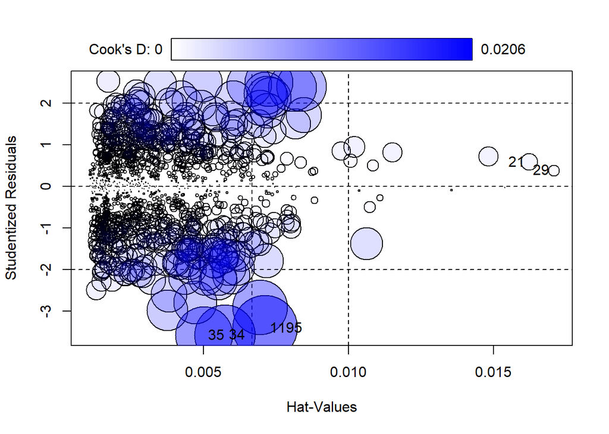

```r
puntosAtipicos <- influencePlot(me)
```

```r
inffluyentesAtipcos = as.numeric(rownames(puntosAtipicos))
modeloSinPuntoM2 = lm(PRES ~ . , aire %>% dplyr :: select(-PM2.5,-hour,-RAIN,-SO2) %>%
              dplyr :: slice(-inffluyentesAtipcos))

summary(modeloSinPuntoM2) #0.6178
```

```
##
## Call:
## lm(formula = PRES ~ ., data = aire %>% dplyr::select(-PM2.5,
##     -hour, -RAIN, -SO2) %>% dplyr::slice(-inffluyentesAtipcos))
##
## Residuals:
##      Min       1Q   Median       3Q      Max
## -17.2446  -4.1415   0.2434   4.1803  14.4769
##
## Coefficients:
##               Estimate Std. Error  t value Pr(>|t|)
## (Intercept)  1.015e+03  6.957e-01 1458.931  < 2e-16 ***
## month        8.009e-01  6.000e-02   13.347  < 2e-16 ***
## NO2         -3.241e-02  5.139e-03   -6.306 4.02e-10 ***
## TEMP        -6.654e-01  1.695e-02  -39.263  < 2e-16 ***
## ---
## Signif. codes:  0 '***' 0.001 '**' 0.01 '*' 0.05 '.' 0.1 ' ' 1
##
## Residual standard error: 5.694 on 1192 degrees of freedom
## Multiple R-squared:  0.6187, Adjusted R-squared:  0.6178
## F-statistic: 644.8 on 3 and 1192 DF,  p-value: < 2.2e-16
```

Volviendo a realizar el mismo proceso que con el modelo anterior, notamos que el modelo sin errores posee un leve incremento de R^2 así que utilizaremos este como el mod2

```r
mod2 = modeloSinPuntoM2
```

Finalmente, el mod2 se definiría de la siguiente forma:

PRES = 1.015e+03 + 8.009e-01(month) - 3.241e-02(NO2) - 6.654e-01(TEMP)

Donde a medida que el valor de TEMP y NO2 aumenta el valor de PRES disminuye, mientras que si el valor de month aumenta la presión también aumenta y si el valor de las tres variables anteriores es cero, la presión seria de 1.015e+03

## Mod3 (Backward)

```r
modelo3 <- stepAIC(lm(PRES ~ ., data = aire),
                 direction = "backward")
```

```
## Start:  AIC=4191.17
## PRES ~ month + hour + PM2.5 + SO2 + NO2 + TEMP + RAIN
##
##         Df Sum of Sq   RSS    AIC
## - PM2.5  1         3 38847 4189.3
## <none>               38844 4191.2
## - RAIN   1       246 39090 4196.7
## - SO2    1       336 39180 4199.5
## - hour   1       349 39194 4199.9
## - NO2    1      1410 40255 4232.0
## - month  1      6179 45023 4366.4
## - TEMP   1     42804 81648 5081.3
##
## Step:  AIC=4189.25
## PRES ~ month + hour + SO2 + NO2 + TEMP + RAIN
##
##         Df Sum of Sq   RSS    AIC
## <none>               38847 4189.3
## - RAIN   1       244 39091 4194.8
## - hour   1       350 39197 4198.0
## - SO2    1       410 39257 4199.9
## - NO2    1      1831 40678 4242.6
## - month  1      6180 45027 4364.6
## - TEMP   1     43642 82489 5091.6
```

```r
summary(modelo3)
```

```
##
## Call:
## lm(formula = PRES ~ month + hour + SO2 + NO2 + TEMP + RAIN, data = aire)
##
## Residuals:
##      Min       1Q   Median       3Q      Max
## -20.2371  -4.1306   0.2573   4.1216  14.9605
##
## Coefficients:
##               Estimate Std. Error  t value Pr(>|t|)
## (Intercept)  1.014e+03  7.424e-01 1365.370  < 2e-16 ***
## month        8.284e-01  6.011e-02   13.782  < 2e-16 ***
## hour         8.192e-02  2.499e-02    3.278 0.001077 **
## SO2          2.634e-02  7.418e-03    3.551 0.000399 ***
## NO2         -4.274e-02  5.698e-03   -7.502 1.22e-13 ***
## TEMP        -6.497e-01  1.774e-02  -36.625  < 2e-16 ***
## RAIN        -6.174e-01  2.254e-01   -2.739 0.006246 **
## ---
## Signif. codes:  0 '***' 0.001 '**' 0.01 '*' 0.05 '.' 0.1 ' ' 1
##
## Residual standard error: 5.704 on 1194 degrees of freedom
## Multiple R-squared:  0.6188, Adjusted R-squared:  0.6169
## F-statistic: 323.1 on 6 and 1194 DF,  p-value: < 2.2e-16
```

Modelo sin datos atipicos

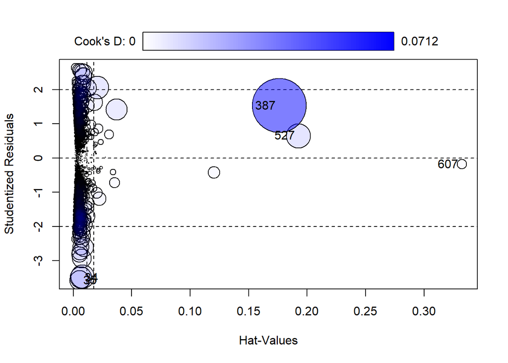

```r
puntosAtipicos3 <- influencePlot(modelo3)
```

```r
inffluyentesAtipcos3 = as.numeric(rownames(puntosAtipicos3))
modeloSinPuntoM3 = lm(PRES ~ . , aire %>% dplyr :: select(-PM2.5) %>%
              dplyr :: slice(-inffluyentesAtipcos3))

summary(modeloSinPuntoM3) #0.6237
```

```
##
## Call:
## lm(formula = PRES ~ ., data = aire %>% dplyr::select(-PM2.5) %>%
##     dplyr::slice(-inffluyentesAtipcos3))
##
## Residuals:
##      Min       1Q   Median       3Q      Max
## -19.6349  -4.1740   0.2641   4.0790  14.9239
##
## Coefficients:
##               Estimate Std. Error  t value Pr(>|t|)
## (Intercept)  1.014e+03  7.378e-01 1374.446  < 2e-16 ***
## month        8.068e-01  5.965e-02   13.525  < 2e-16 ***
## hour         7.531e-02  2.479e-02    3.038 0.002430 **
## SO2          2.621e-02  7.347e-03    3.567 0.000375 ***
## NO2         -4.251e-02  5.642e-03   -7.535 9.65e-14 ***
## TEMP        -6.537e-01  1.759e-02  -37.157  < 2e-16 ***
## RAIN        -1.184e+00  4.054e-01   -2.919 0.003576 **
## ---
## Signif. codes:  0 '***' 0.001 '**' 0.01 '*' 0.05 '.' 0.1 ' ' 1
##
## Residual standard error: 5.646 on 1189 degrees of freedom
## Multiple R-squared:  0.6256, Adjusted R-squared:  0.6237
## F-statistic: 331.1 on 6 and 1189 DF,  p-value: < 2.2e-16
```

Al igual que en los dos casos anteriores, el modelo sin datos atípicos muestra un leve incremento en el R^2 por ende escogeremos este

```r
mod3 = modeloSinPuntoM3
```

Finalmente, el mod3 se definiría de la siguiente forma:

PRES = 1.014e+03 + 8.068e-01(month) + 7.531e-02(hour) + 2.621e-02(SO2) - 4.251e-02(NO2) - 6.537e-01(TEMP) - 1.184e+00(RAIN)

Las variables month, hour y SO2 en este caso aumentan el valor de PRES, mientras que las variables NO2, TEMP y rain disminuyen la temperatura, en caso de que todas las variables sean cero el valor de la presión será 1.014e+03

# Selección de modelo

## Supuestos

### Normalidad

#### mod1

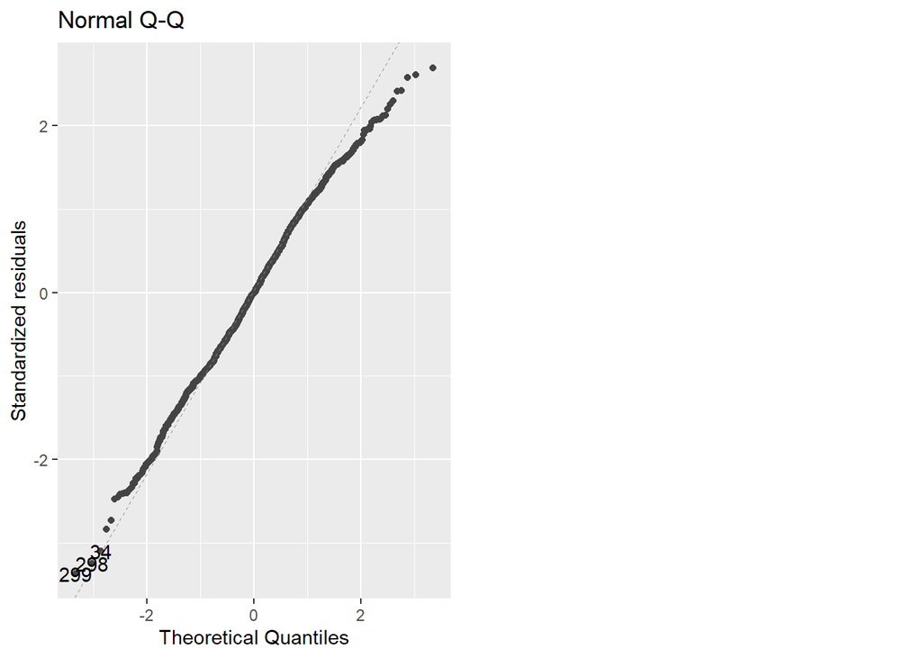

```r
autoplot(mod1)[2]
```

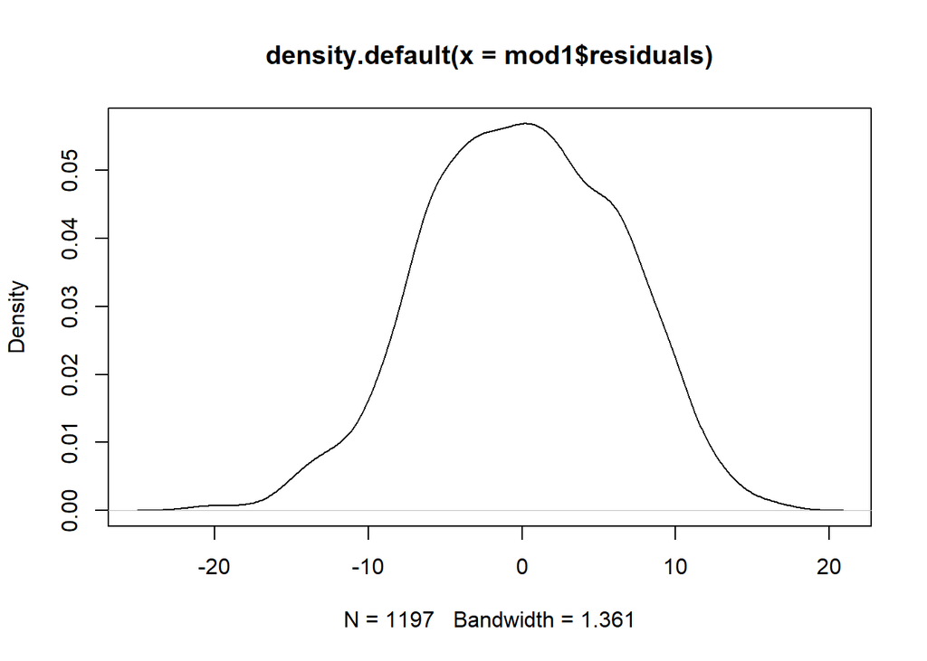

```r
plot(density(mod1$residuals))
```

```r
nortest::lillie.test(mod1$residuals) #0.01092
```

```
##
##  Lilliefors (Kolmogorov-Smirnov) normality test
##
## data:  mod1$residuals
## D = 0.030496, p-value = 0.01092
```

#### mod2

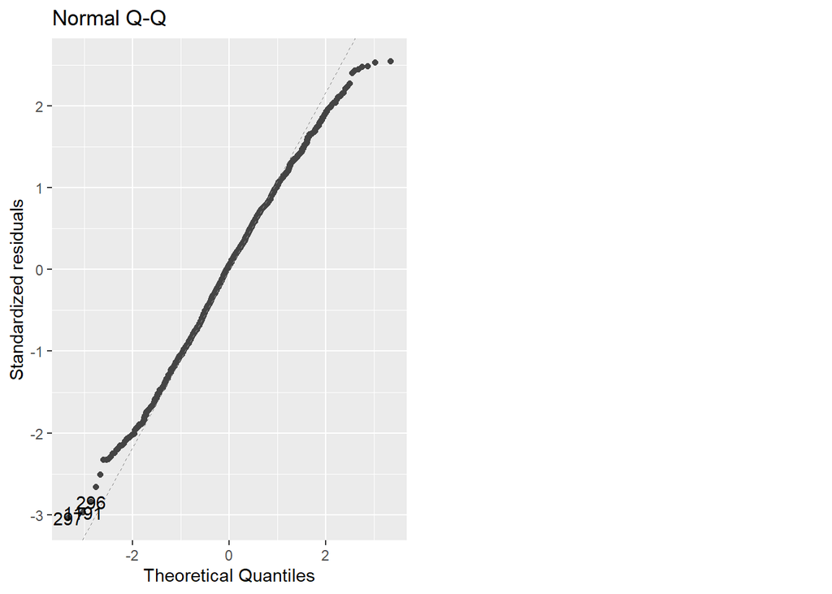

```r
autoplot(mod2)[2]
```

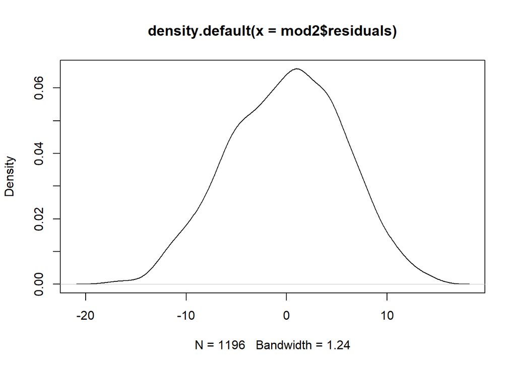

```r
plot(density(mod2$residuals))
```

```r
nortest::lillie.test(mod2$residuals) #0.06737
```

```
##
##  Lilliefors (Kolmogorov-Smirnov) normality test
##
## data:  mod2$residuals
## D = 0.0254, p-value = 0.06737
```

- Las colas de la distribución no se alejan tanto de la recta de los cuantiles normales en el grafico Q-Q
- El grafico de densidad muestra una semejanza a una distribución normal
- El p-value es mayor a 0.05
- **Cumple con el supuesto de normalidad**

#### mod3

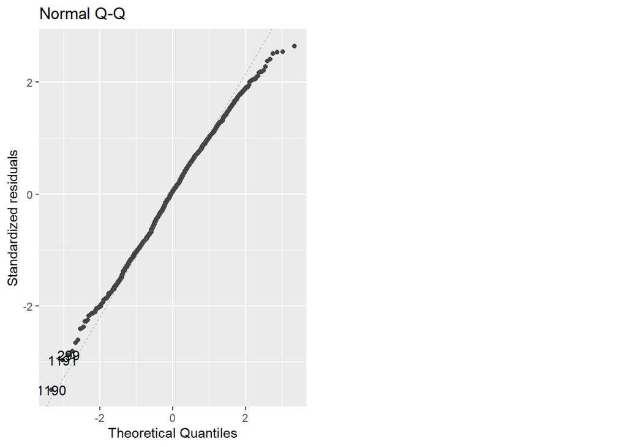

```r
autoplot(mod3)[2]
```

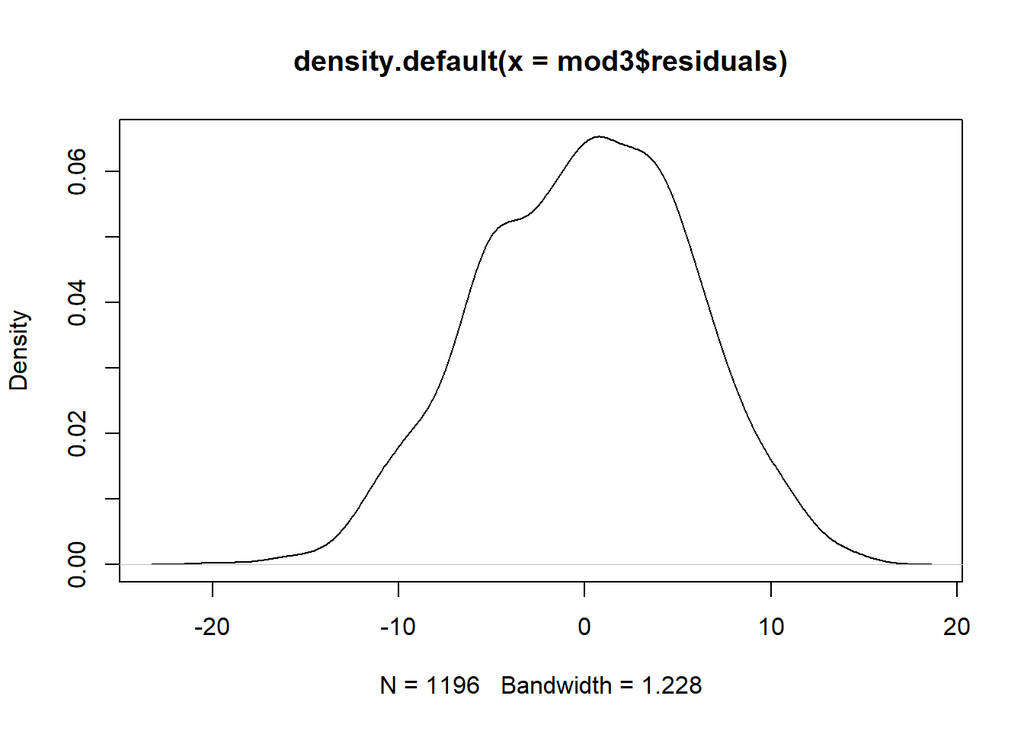

```r
plot(density(mod3$residuals))
```

```r
nortest::lillie.test(mod3$residuals) #0.03052
```

```
##
##  Lilliefors (Kolmogorov-Smirnov) normality test
##
## data:  mod3$residuals
## D = 0.027773, p-value = 0.03052
```

- Las colas de la distribución parecen acercarse un poco a la recta de los cuantiles normales en el grafico Q-Q
- El grafico de la densidad no muestra un comportamiento normal
- El p-value es menor a 0.05
- **No cumple con el supuesto de normalidad**

### Independencia

#### mod1

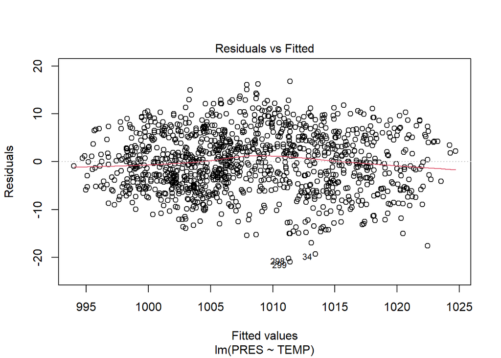

```r
plot(mod1,which = 1)
```

```r
lmtest::dwtest(mod1) #2.2e-16
```

```
##
##  Durbin-Watson test
##
## data:  mod1
## DW = 0.26419, p-value < 2.2e-16
## alternative hypothesis: true autocorrelation is greater than 0
```

- El p-value es muy cercano a cero
- **No cumple con el supuesto de independencia**

#### mod2

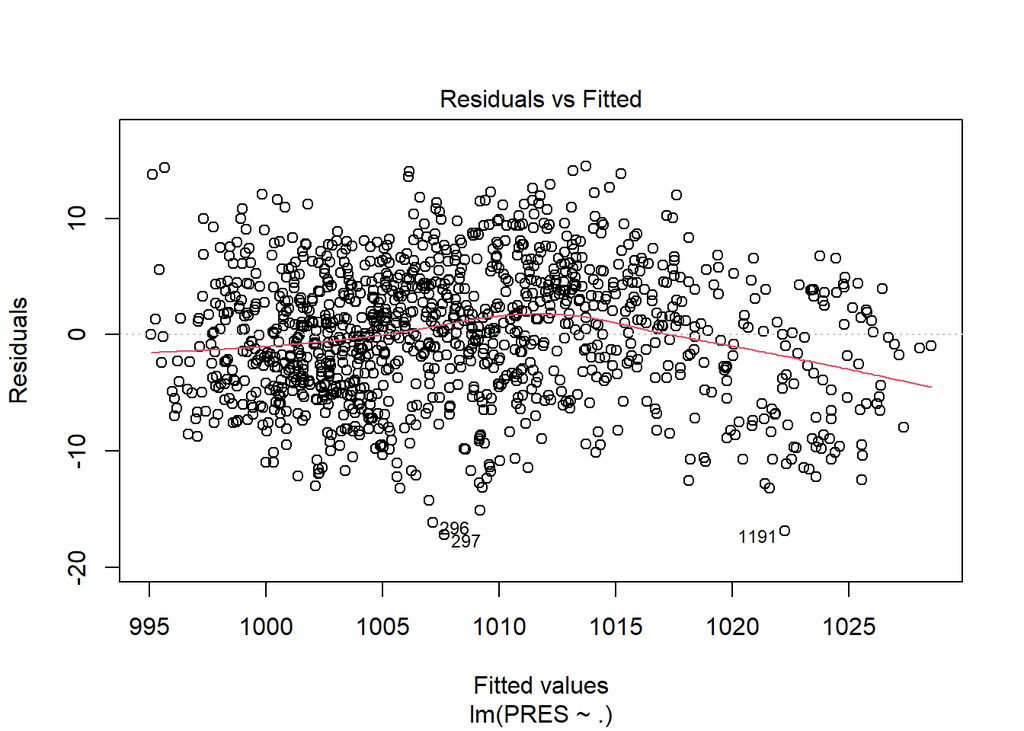

```r
plot(mod2,which = 1)
```

```r
lmtest::dwtest(mod2)#2.2e-16
```

```
##
##  Durbin-Watson test
##
## data:  mod2
## DW = 0.28097, p-value < 2.2e-16
## alternative hypothesis: true autocorrelation is greater than 0
```

- El p-value es muy cercano a cero
- **No cumple con el supuesto de independencia**